# 20220103

Takala

2022年に注目すべき鉄道関連イベントは，西九州新幹線の開業と只見線の全線復旧だ．

- [2022年度秋頃に西九州新幹線が開業します!｜JR九州](https://www.jrkyushu.co.jp/train/nishikyushu/)

西九州新幹線は約70kmの区間が開業する． すでにある九州新幹線とは物理的に接続しない区間の開業となる．在来線特急との対面乗り換えで形式的な接続はされるが，飛び地という感じで不思議な感覚だ．

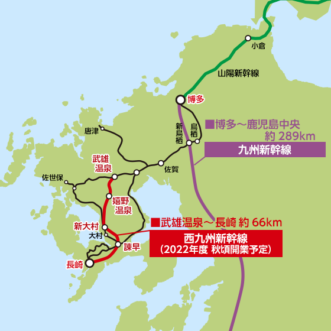

西九州新幹線の開業区間

只見線は2011年の豪雨により不通となっている． 2011年の東北というと，東日本大震災が印象的であり太平洋沿岸地域の 復興が焦点に当てられがちだが，只見線も奇しくも2011年から長らく不通となっているのだ．

只見線は秘境線として有名で，沿線の景色がとてつもなく素晴らしい． 私も只見線に沿ってドライブをしたことがあるがとても楽しかった．

- [只見線の歴史 | 只見線ポータルサイト](https://tadami-line.jp/history/)

余談だが東日本大震災と鉄道に関しては，石油臨時列車に関するエピソードが 感動的である．知っておいて損はない．

[【東日本大震災から10年】被災地へ走った“前例なき”緊急石油貨物列車。鉄道マンたちの挑戦(前編)｜読むらじる。｜NHKラジオ らじる★らじる](https://www.nhk.or.jp/radio/magazine/article/tetsutabi/Di2MqJRESL.html)